# Introduction to PySAL

After watching [Luc Anselin](http://geoplan.asu.edu/anselin) give a talk about [adapting geospatial analysis to accommodate modern scientific workflows](http://www.youtube.com/watch?v=ZZeL8yDmfq4), I watched a [follow up video](http://www.youtube.com/watch?v=FN1nH4Fkd_Y) in which [Sergio Rey](http://geoplan.asu.edu/rey) discussed PySAL, the cornerstone of the analytical stack that Anselin and Rey (among others) are developing at ASU. One of the things that was immediately clear from the video was the impressive gulf in computational speed between the Python based spatial package and R's [spdep](http://cran.r-project.org/web/packages/spdep/index.html).

R will no doubt remain essential for both visualization and some routines that may not be available in the younger PySAL, but the advantage of integrating [pandas](http://pandas.pydata.org/) more seamlessly into the manipulation of spatial data is just to great to ignore. Moreover, again, it's faster. Thus, this script is meant to introduce the functionality as I have done with the R packages. Surprise! PySAL was already included in the Anaconda suite, I just didn't know what it was.

To start, let's look at the broad overview.

```python
import numpy as np
import pandas as pd
from pandas import Series,DataFrame
import pysal
help(pysal)
```

```
Help on package pysal:

NAME
    pysal

FILE
    /home/choct155/analysis/Anaconda/lib/python2.7/site-packages/pysal/__init__.py

DESCRIPTION
    Python Spatial Analysis Library
    ===============================


    Documentation
    -------------
    PySAL documentation is available in two forms: python docstrings and an html         webpage at http://pysal.org/

    Available sub-packages
    ----------------------

    cg
        Basic data structures and tools for Computational Geometry
    core
        Basic functions used by several sub-packages
    esda
        Tools for Exploratory Spatial Data Analysis
    examples
        Example data sets used by several sub-packages for examples and testing
    region
        Regionalization algorithms and spatially constrained clustering
    spatial_dynamics
        Space-time exploratory methods and clustering
    spreg
        Spatial regression and econometrics
    weights
        Tools for creating and manipulating weights
    contrib
        Package for interfacing with third-party libraries

    Utilities
```

[output cut: 12 more lines]

```
    region (package)
    spatial_dynamics (package)
    spreg (package)
    test_NameSpace
    version
    weights (package)

SUBMODULES
    IOHandlers
    directional
    ergodic

DATA
    MISSINGVALUE = None
    version = '1.5.0'
```

I see spatial econometrics, weights, and space-time capability. Perhaps this also has the advantage of not requiring as many packages to ge the job done? Supposedly there is example data available.

```python
!ls /home/choct155/analysis/Anaconda/lib/python2.7/site-packages/pysal/examples
```

```
10740.dbf	   geobugs_scot      Polygon.dbf	      stata_full.txt
10740_queen.gal    __init__.py	     Polygon.prj	      stata_sparse.txt
10740_rook.gal	   __init__.pyc      Polygon.shp	      states48.gal
10740.shp	   juvenile.dbf      Polygon.shx	      stl.gal
10740.shx	   juvenile.gwt      README.txt		      stl_hom.csv
arcgis_ohio.dbf    juvenile.html     rook31.dbf		      stl_hom.dbf
arcgis_txt.txt	   juvenile.shp      rook31.gal		      stl_hom.html
book.gal	   juvenile.shx      rook31.shp		      stl_hom_rook.gal
book.txt	   lattice10x10.shp  rook31.shx		      stl_hom.shp
burkitt.dbf	   lattice10x10.shx  sacramentot2.dbf	      stl_hom.shx
burkitt.shp	   Line.dbf	     sacramentot2.gal	      stl_hom.txt
burkitt.shx	   Line.prj	     sacramentot2.sbn	      stl_hom.wkt
calempdensity.csv  Line.shp	     sacramentot2.sbx	      us48.dbf
Chicago77.dbf	   Line.shx	     sacramentot2.shp	      us48.shp
Chicago77.shp	   mexico.csv	     sacramentot2.shx	      us48.shx
Chicago77.shx	   mexico.gal	     sids2.dbf		      usjoin.csv
columbus.dbf	   NAT.dbf	     sids2.gal		      virginia.dbf
columbus.gal	   NAT.shp	     sids2.html		      virginia.gal
columbus.html	   NAT.shx	     sids2.shp		      virginia.prj
columbus.shp	   ohio.swm	     sids2.shx		      virginia_rook.gal
columbus.shx	   Point.dbf	     spat-sym-us.mat	      virginia.shp
desmith.gal	   Point.prj	     spat-sym-us.wk1	      virginia.shx
desmith.txt	   Point.shp	     spdep_listw2WB_columbus  wmat.dat
examples.txt	   Point.shx	     spi_download.csv	      wmat.mtx
```

I guess they were telling the truth.

## I/O

The array of input/output formats that can be handled by the abstract **pysal.open** method is remarkably lengthy. I am only going to demonstrate shapefiles capability (because that's what I have been dealing with), but full list of handled formats appears below.

```python
pysal.open.check()
```

```
PySAL File I/O understands the following file extensions:
Ext: '.shp', Modes: ['r', 'wb', 'w', 'rb']
Ext: '.mtx', Modes: ['r', 'w']
Ext: '.swm', Modes: ['r', 'w']
Ext: '.mat', Modes: ['r', 'w']
Ext: '.shx', Modes: ['r', 'wb', 'w', 'rb']
Ext: '.stata_text', Modes: ['r', 'w']
Ext: '.geoda_txt', Modes: ['r']
Ext: '.dbf', Modes: ['r', 'w']
Ext: '.dat', Modes: ['r', 'w']
Ext: '.gwt', Modes: ['r', 'w']
Ext: '.gal', Modes: ['r', 'w']
Ext: '.arcgis_text', Modes: ['r', 'w']
Ext: '.kwt', Modes: ['r', 'w']
Ext: '.arcgis_dbf', Modes: ['r', 'w']
Ext: '.geobugs_text', Modes: ['r', 'w']
Ext: '.wk1', Modes: ['r', 'w']
Ext: '.csv', Modes: ['r']
Ext: '.wkt', Modes: ['r']
```

```python
#Establish directory location
ex_dir='/home/choct155/analysis/Anaconda/lib/python2.7/site-packages/pysal/examples/'

#Read in shapefile
shp=pysal.open(ex_dir+'10740.shp')
print type(shp)
print shp
print '\n\n'

#Iterate through shapefile
poly=shp.next()
print type(poly)
print poly
```

```
<class 'pysal.core.IOHandlers.pyShpIO.PurePyShpWrapper'>
<pysal.core.IOHandlers.pyShpIO.PurePyShpWrapper object at 0x4ae8ed0>



<class 'pysal.cg.shapes.Polygon'>
<pysal.cg.shapes.Polygon object at 0x4ae8f90>
```

Note that the initial read in is housed in an iterator wrapper. I could be wrong, but I think that, like generators, these constructs are only realized in real-time (unlike lists which exist to their full extent upon definition). They are basically containers for the data types being held (in this case, polygons). For this reason, a step through is needed to get to an actual polygon object. I suspect that this is designed to limit memory loads. Again, this is a guess from a limited knowledge base.

Polygon objects (or any vector data type), in turn, hold their own information. If I had to guess, I would say that the polygon objects hold coordinate vectors defining the enclosure.

This is the reason for the disparity in lengths seen below.

```python
print len(shp)
print len(poly)
```

```
195
63
```

The length of the shapefile is defined by the number of polygons it contains.

```python
for i in range(5):
    print list(shp)[i]
```

```
<pysal.cg.shapes.Polygon object at 0x4ae8c50>
<pysal.cg.shapes.Polygon object at 0x4ae8b50>
<pysal.cg.shapes.Polygon object at 0x4ae8a90>
<pysal.cg.shapes.Polygon object at 0x4ae8d50>
<pysal.cg.shapes.Polygon object at 0x4ae8dd0>
```

More on this later...

## Spatial Weights

PySAL supports three general types of weight matrices: >1. [Contiguity Based](http://pysal.org/library/weights/Contiguity.html)

> 2. [Distance Based](http://www.pysal.org/library/weights/Distance.html)
> 3. [Kernel Based](http://pysal.org/1.3/library/weights/user.html)

PySAL weights are handled by objects of class *pysal.weights.W*. Because weight matrices can be very large while also very sparse, instead of the tradition nxn matrix, weights are stored as two dictionaries. One of these dictionaries stores all possible neighbors for each observation, and the other stores the weight values for each of these observation/neighbor constructs (in the same order).

#### Contiguity Based Weights

A simple 5x5 contiguity matrix can be constructed with the **lat2W** method.

```python
#Create matrix
w=pysal.lat2W(5,5)
print w
```

```
<pysal.weights.weights.W object at 0x4ae8e10>
```

We can inspect the number of observations and the degree of sparseness.

```python
print w.n
print w.pct_nonzero
```

```
25
0.128
```

We can also inspect those dictionaries we discussed above. Neighbors are represented by integer values indicating the index position of the said neighbor. Weights are represented by float values which, again, apply to the corresponding position in the neighbor dictionary.

```python
print w.neighbors
print w.weights
```

```
{0: [5, 1], 1: [0, 6, 2], 2: [1, 7, 3], 3: [2, 8, 4], 4: [3, 9], 5: [0, 10, 6], 6: [1, 5, 11, 7], 7: [2, 6, 12, 8], 8: [3, 7, 13, 9], 9: [4, 8, 14], 10: [5, 15, 11], 11: [6, 10, 16, 12], 12: [7, 11, 17, 13], 13: [8, 12, 18, 14], 14: [9, 13, 19], 15: [10, 20, 16], 16: [11, 15, 21, 17], 17: [12, 16, 2…
{0: [1.0, 1.0], 1: [1.0, 1.0, 1.0], 2: [1.0, 1.0, 1.0], 3: [1.0, 1.0, 1.0], 4: [1.0, 1.0], 5: [1.0, 1.0, 1.0], 6: [1.0, 1.0, 1.0, 1.0], 7: [1.0, 1.0, 1.0, 1.0], 8: [1.0, 1.0, 1.0, 1.0], 9: [1.0, 1.0, 1.0], 10: [1.0, 1.0, 1.0], 11: [1.0, 1.0, 1.0, 1.0], 12: [1.0, 1.0, 1.0, 1.0], 13: [1.0, 1.0, 1.0, 1…
```

We can even inspect the cardinality of neighbor relations with the **histogram** method. The method returns a list of tuples in which the first position indicates the number of neighbors that exist for a given observation, and the second position indicates how many observations fall into that category. It being nothing more than a list of tuples, we can easily use list comprehensions to integrate pandas plotting capability.

```
[(2, 4), (3, 12), (4, 9)]
Axes(0.125,0.125;0.775x0.775)
```

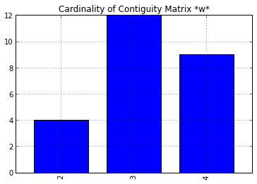

```python
#Extract neighbor relation cardinality
print w.histogram

#Integrate pandas plot for visual display
print Series([y for x,y in w.histogram],index=[x for x,y in w.histogram]).plot(kind='bar',\
                                                                               title='Cardinality of Contiguity Matrix *w*')
```

The default contiguity matrix behavior is the rook criterion. Queen and bishop criteria are also available, although the latter is calculated as the difference between queen and rook. Just as a reminder, rook contiguity requires a shared edge (two vertices). Queen requires only one, but also accepts shared edges. Bishop contiguity mandates only one shared vertex.

Watch how the cardinality shifts with the queen behavior.

```
[(3, 4), (4, 0), (5, 12), (6, 0), (7, 0), (8, 9)]
Axes(0.125,0.125;0.775x0.775)
```

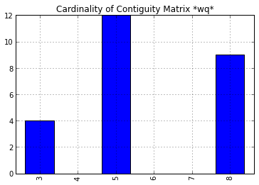

```python
#Create queen contiguity matrix
wq=pysal.lat2W(5,5,rook=False)

#Examine cardinality
print wq.histogram

#Integrate pandas plot for visual display
print Series([y for x,y in wq.histogram],index=[x for x,y in wq.histogram]).plot(kind='bar',\
                                                                               title='Cardinality of Contiguity Matrix *wq*')
```

This is all well and good, but listen here guy, who the F uses regular grids in social science anyway? It turns out contiguity weight matrices can be constructed directly from the observations in a shapefile. BOOM!

```
[(2, 7), (3, 10), (4, 17), (5, 8), (6, 3), (7, 3), (8, 0), (9, 1)]
Axes(0.125,0.125;0.775x0.775)
```

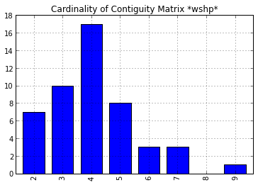

```python
#Use shapefile to define neighbors
w_shp=pysal.rook_from_shapefile(ex_dir+'columbus.shp')

#Examine cardinality
print w_shp.histogram

#Integrate pandas plot for visual display
print Series([y for x,y in w_shp.histogram],index=[x for x,y in w_shp.histogram]).plot(kind='bar',\
                                                                               title='Cardinality of Contiguity Matrix *wshp*')
```

Yes, **queen_from_shapefile** is also an acceptable method. And yes, this is easier to do here than in R.

#### k-Nearest Neighbor Weights

k-nearest neighbor weights can be constructed from the centroids of our regular lattice. We actually use numpy here to create the coordinate array.

```python
#Basically create two ndarrays, where y is the transpose of x
x,y=np.indices((5,5))

#Convert both from matrices to 1-d vectors
x.shape=(25,1)
y.shape=(25,1)

#Concatenate along the length, and bundle as coordinate pairs
data=np.hstack([x,y])
print data
```

```
[[0 0]
 [0 1]
 [0 2]
 [0 3]
 [0 4]
 [1 0]
 [1 1]
 [1 2]
 [1 3]
 [1 4]
 [2 0]
 [2 1]
 [2 2]
 [2 3]
 [2 4]
 [3 0]
 [3 1]
 [3 2]
 [3 3]
 [3 4]
 [4 0]
 [4 1]
 [4 2]
 [4 3]
 [4 4]]
```

We then use the **knnW** method to define our neighbors.

```python
wknn3=pysal.knnW(data,k=3)
print wknn3
```

```
<pysal.weights.weights.W object at 0x4cd7510>
```

Neighbors and weights can be viewed in the same way.

```python
print wknn3.neighbors
print wknn3.weights
```

```
{0: [1, 5, 6], 1: [0, 2, 6], 2: [1, 3, 7], 3: [2, 4, 8], 4: [3, 9, 8], 5: [0, 6, 10], 6: [1, 5, 7], 7: [2, 6, 12], 8: [3, 9, 13], 9: [4, 8, 14], 10: [5, 11, 15], 11: [6, 10, 16], 12: [7, 11, 17], 13: [8, 14, 18], 14: [9, 13, 19], 15: [10, 16, 20], 16: [15, 17, 21], 17: [16, 18, 22], 18: [17, 19, 23]…
{0: [1, 1, 1], 1: [1, 1, 1], 2: [1, 1, 1], 3: [1, 1, 1], 4: [1, 1, 1], 5: [1, 1, 1], 6: [1, 1, 1], 7: [1, 1, 1], 8: [1, 1, 1], 9: [1, 1, 1], 10: [1, 1, 1], 11: [1, 1, 1], 12: [1, 1, 1], 13: [1, 1, 1], 14: [1, 1, 1], 15: [1, 1, 1], 16: [1, 1, 1], 17: [1, 1, 1], 18: [1, 1, 1], 19: [1, 1, 1], 20: [1, 1…
```

Note that observation 0 ([0 0]) is neighbored by observations 1 ([0 1]), 5 ([1 0]), and 6 ([1 1]). Note also that k-nearest assigns the same weight value to all applicable neighbors.

Note that we can also build k-nearest from a shapefile.

```python
#Use shapefile to define neighbors
w_knn=pysal.knnW_from_shapefile(ex_dir+'columbus.shp',k=4)

#Examine neighbors
print w_knn.neighbors
```

```
{0: [2, 1, 3, 7], 1: [3, 0, 7, 2], 2: [4, 3, 0, 7], 3: [7, 1, 6, 2], 4: [10, 7, 2, 14], 5: [8, 4, 9, 2], 6: [12, 7, 13, 3], 7: [3, 6, 12, 11], 8: [21, 5, 25, 14], 9: [16, 8, 19, 22], 10: [11, 12, 15, 14], 11: [10, 12, 13, 15], 12: [13, 11, 10, 18], 13: [12, 18, 11, 17], 14: [15, 24, 10, 25], 15: [17…
```

#### Distance Band Weights

If we don't think that the number of neighbors is as important as distance, we can work with distance thresholds. The process is quite similar, though this time we use the **threshold_binaryW_from_array** to work on our previously constructed data. A cardinality plot would be more interesting in this case...

```
Axes(0.125,0.125;0.775x0.775)
```

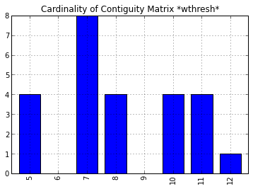

```python
#Create distance weights using 'data'
wthresh=pysal.threshold_binaryW_from_array(data,2)

#Integrate pandas plot for visual display
print Series([y for x,y in wthresh.histogram],index=[x for x,y in wthresh.histogram]).plot(kind='bar',\
                                                                               title='Cardinality of Contiguity Matrix *wthresh*')
```

If we are generating the matrix from a shapefile, we must first determine the minimum nearest neighbor distance so that each unit has at least one neighbor. Then, we proceed in the same fashion...

```
Axes(0.125,0.125;0.775x0.775)
```

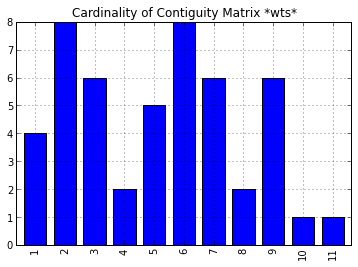

```python
#Find minimum threshold
thresh=pysal.min_threshold_dist_from_shapefile(ex_dir+'columbus.shp')

#Generate weights
wts=pysal.threshold_binaryW_from_shapefile(ex_dir+'columbus.shp',thresh)

#Integrate pandas plot for visual display
print Series([y for x,y in wts.histogram],index=[x for x,y in wts.histogram]).plot(kind='bar',\
                                                                               title='Cardinality of Contiguity Matrix *wts*')
```

**threshold_continuousW_from_array** permits float weights and even provides an *alpha* option for decay rates.

#### Kernel Weights

Kernel weights combine distance band considerations with pre-defined decay functions. Rather than using a linear decay with *alpha*, kernel weights enable options like 'gaussian' or 'quadratic' via the *function* argument. *Bandwidth* handles the distance element in this method. Setting *fixed* to False enables adaptive bandwidths to be set endogenously.

```python
#Generate point features
points = [(10, 10), (20, 10), (40, 10), (15, 20), (30, 20), (30, 30)]

#Generate weights
kweag = pysal.Kernel(points,fixed = False,function = 'gaussian')

print kweag.neighbors
print kweag.weights
```

```
{0: [0, 1, 3], 1: [1, 0, 3], 2: [2, 4, 1], 3: [3, 0, 1], 4: [4, 5, 2], 5: [5, 4, 3]}
{0: [0.3989422804014327, 0.2674190291577696, 0.2419707487162134], 1: [0.3989422804014327, 0.2674190291577696, 0.2419707487162134], 2: [0.3989422804014327, 0.31069657591175387, 0.2419707487162134], 3: [0.3989422804014327, 0.2419707487162134, 0.2419707487162134], 4: [0.3989422804014327, 0.310696575911…
```

#### More with Weights

We won't get into too much more detail, but suffice it to say that there are a number of useful methods for dealing with weight matrices. We can view weight sums with **pysal.W.s0**, and view the full on sparse matrix with **pysal.W.full**. There are also useful methods for transformations and extracting commonly needed information from weight matrices in the [docs](http://pysal.org/1.3/users/tutorials/weights.html#pysal-spatial-weight-types).

## Spatial Lags

Spatial lags are a critical piece of infrastructure for spatial econometrics, so I will take some space here to examine their construction. We will be using a regular lattice, but the concepts are applicable to shapefiles as well.

```python
#Generate lattice
w=pysal.lat2W(3,3)

#Create phony 'attributes'
y=np.arange(w.n)

y
```

```
array([0, 1, 2, 3, 4, 5, 6, 7, 8])
```

The spatial lag is the weighted sum of neighboring attribute values: $yl_i=\sum_jw_{i,j}y_j$

```python
#Row standardize our weight matrix
w.transform='r'

#Generate spatial lags
yl=pysal.lag_spatial(w,y)

yl
```

```
array([ 2.        ,  2.        ,  3.        ,  3.33333333,  4.        ,
        4.66666667,  5.        ,  6.        ,  6.        ])
```

It is crucial that the attribute values correspond appropriately with the features in the shapefile. Usually, however, these items come from the same data source.

```python
#Create weight matrix from shapefile
w=pysal.rook_from_shapefile(ex_dir+'columbus.shp')

#Grab associated data table
f=pysal.open(ex_dir+'columbus.dbf')
type(f)
```

```
pysal.core.IOHandlers.pyDbfIO.DBF
```

Since relations between variables the adding or removal of variables will be common, this is a place at which it would be convenient to integrate pandas. Fortunately, there are many ways to build DataFrames, so this actually isn't very labor intensive even though there is no direct conversion method. In fact, we can create our own function. The reason is that PySAL enables base Python and numpy representations of .dbf datasets.

```python
def dbf2DF(dbf):
    """Converts .dbf data into pandas DataFrame.
    Requires: pandas, PySAL"""
    #Grab list of column names
    dbf_cols=dbf.header

    #Grab list of data arrays associated with said column names
    dbf_data=[]
    for col in dbf_cols:
        dbf_data.append(dbf.by_col[col])

    #Create data dictionary
    dbf_dict=dict(zip(dbf_cols,dbf_data))

    #Generate DataFrame
    dbf_df=DataFrame(dbf_dict)
    return dbf_df

col_data=dbf2DF(f)
col_data.head()
```

|  | AREA | COLUMBUS_ | COLUMBUS_I | CP | CRIME | DISCBD | EW | HOVAL | INC | NEIG | NEIGNO | NSA | NSB | OPEN | PERIMETER | PLUMB | POLYID | THOUS | X | Y |
| --- | --- | --- | --- | --- | --- | --- | --- | --- | --- | --- | --- | --- | --- | --- | --- | --- | --- | --- | --- | --- |
| 0 | 0.309441 | 2 | 5 | 0 | 15.725980 | 5.03 | 1 | 80.467003 | 19.531 | 5 | 1005 | 1 | 1 | 2.850747 | 2.440629 | 0.217155 | 1 | 1000 | 38.799999 | 44.070000 |
| 1 | 0.259329 | 3 | 1 | 0 | 18.801754 | 4.27 | 0 | 44.567001 | 21.232 | 1 | 1001 | 1 | 1 | 5.296720 | 2.236939 | 0.320581 | 2 | 1000 | 35.619999 | 42.380001 |
| 2 | 0.192468 | 4 | 6 | 0 | 30.626781 | 3.89 | 1 | 26.350000 | 15.956 | 6 | 1006 | 1 | 1 | 4.534649 | 2.187547 | 0.374404 | 3 | 1000 | 39.820000 | 41.180000 |
| 3 | 0.083841 | 5 | 2 | 0 | 32.387760 | 3.70 | 0 | 33.200001 | 4.477 | 2 | 1002 | 1 | 1 | 0.394427 | 1.427635 | 1.186944 | 4 | 1000 | 36.500000 | 40.520000 |
| 4 | 0.488888 | 6 | 7 | 0 | 50.731510 | 2.83 | 1 | 23.225000 | 11.252 | 7 | 1007 | 1 | 1 | 0.405664 | 2.997133 | 0.624596 | 5 | 1000 | 40.009998 | 38.000000 |

Recall that the **DataFrame.values** method returns a numpy array, which is needed in the construction of spatial lags.

```python
col_data['INC'].values
```

```
array([ 19.531   ,  21.232   ,  15.956   ,   4.477   ,  11.252   ,
        16.028999,   8.438   ,  11.337   ,  17.586   ,  13.598   ,
         7.467   ,  10.048   ,   9.549   ,   9.963   ,   9.873   ,
         7.625   ,   9.798   ,  13.185   ,  11.618   ,  31.07    ,
        10.655   ,  11.709   ,  21.155001,  14.236   ,   8.461   ,
         8.085   ,  10.822   ,   7.856   ,   8.681   ,  13.906   ,
        16.940001,  18.941999,   9.918   ,  14.948   ,  12.814   ,
        18.739   ,  17.017   ,  11.107   ,  18.476999,  29.833   ,
        22.207001,  25.872999,  13.38    ,  16.961   ,  14.135   ,
        18.323999,  18.950001,  11.813   ,  18.796   ])
```

In any event, proceeding with the spatial lag construction.

```python
#Row standardize weights
w.transform='r'

#Generate lags
yl=pysal.lag_spatial(w,col_data['INC'].values)
yl
```

```
array([ 18.594     ,  13.32133333,  14.123     ,  14.94425   ,
        11.817857  ,  14.419     ,  10.283     ,   8.3364    ,
        11.7576665 ,  19.48466667,  10.0655    ,   9.1882    ,
         9.483     ,  10.07716667,  11.231     ,  10.46185714,
        21.94100033,  10.8605    ,  12.46133333,  15.39877778,
        14.36333333,  15.0838    ,  19.93666633,  10.90833333,
         9.7       ,  11.403     ,  15.13825   ,  10.448     ,
        11.81      ,  12.64725   ,  16.8435    ,  26.0662505 ,
        15.6405    ,  18.05175   ,  15.3824    ,  18.9123996 ,
        12.2418    ,  12.76675   ,  18.5314995 ,  22.79225025,
        22.575     ,  16.8435    ,  14.2066    ,  14.20075   ,
        15.2515    ,  18.6079995 ,  26.0200005 ,  15.818     ,  14.303     ])
```

## Shapefile Visualization

It appears that visualization with PySAL has a long way to go before coming close to touching [ggplot2](http://ggplot2.org/) in R. However, apparently there is some functionality, which may serve to provide enough to identify where greater resources are required.

```python
from pysal.contrib.viz import mapping as map
```

[output not shown]

```python
import GDAL
import ogr
```

[output not shown]

```python
from osgeo import gdal
```

[output not shown]